# R Bootcamp HTML Slides

Jared Knowles

2012/05/13

# R

- R is an Open Source (and freely available) environment for statistical computinga nd graphics
- Available for Windows, Mac OS X, and Linux
- R is being actively developed with two major releases per year and dozens of releases of add on packages
- R can be extended with ‘packages’ that contain data, code, and documentation to add new functionality

# Why Use R

- R is a common tool among data experts at major universities
- No need to go through procurement, R can be installed in any environment on any machine and used with no licensing or agreements needed
- R source code is very readable to increase transparency of processes
- R code is easily borrowed from and shared with others
- R is incredibly flexible and can be adapted to specific local needs
- R is under incredibly active development, improving greatly, and supported wildly by both professional and academic developers

# R Advantages Continued

- R is platform agnostic–Linux, Mac, PC, server, desktop, etc.
- R can output results in a variety of formats
- R can build routines straight out of a database for common and universal reporting

## R Can Compliment Other Tools

- R plays nicely with data from Stata, SPSS, SAS and others
- R can check work, produce output, visualize results from other programs
- R can do bleeding edge analysis that aren’t available in proprietary packages yet
- R is becoming more prevalent in undergraduate statistics courses

# R As A Calculator

```r
2 + 2  # add numbers
```

```
## [1] 4
```

```r
2 * pi  #multiply by a constant
```

```
## [1] 6.283
```

```r
7 + runif(1, min = 0, max = 1)  #add a random variable
```

```
## [1] 7.555
```

```r
4^4  # powers
```

```
## [1] 256
```

```r
sqrt(4^4)  # functions
```

```
## [1] 16
```

# Using the Workspace

- To do more we need to learn how to manipulate the ‘workspace’.
- This includes all the scalars, vectors, datasets, and functions stored in memory.
- All R objects are stored in the memory of the computer, limiting the available space for calculation to the size of the RAM on your machine.
- R makes organizing the workspace easy.

```r
x <- 5  #store a variable with <-
x  #print the variable
```

```
## [1] 5
```

```r
z <- 3
ls()  #list all variables
```

```
## [1] "x" "z"
```

```r
ls.str()  #list and describe variables
```

```
## x :  num 5
## z :  num 3
```

```r
rm(x)  # delete a variable
ls()
```

```
## [1] "z"
```

# R as a Language

- R is more than statistical software, it is a computer language
- Like any language it has rules (some poorly enforced), and conventions
- You will learn more as you go, but we’ll go over a few to start
1. Case sensitivity matters

```r
a <- 3
A <- 4
print(c(a, A))
```

```
## [1] 3 4
```

- **a** ≠ **A**
2. What happens if I type **print(a,A)**?
- So what does **c** do?

```r
A <- c(3, 4)
print(A)
```

```
## [1] 3 4
```

- **c** stands for concatenate and allows vectors to have multiple elements

# Vectors

- Everything is a vector in R, even single numbers

```r
print(1)
```

```
## [1] 1
```

```r
# The 1 in braces means this element is a vector of length 1
print("This tutorial is awesome")
```

```
## [1] "This tutorial is awesome"
```

```r
# This is a vector of length 1 consisting of a single 'string of
# characters'
print(LETTERS)
```

```
##  [1] "A" "B" "C" "D" "E" "F" "G" "H" "I" "J" "K" "L" "M" "N" "O" "P" "Q"
## [18] "R" "S" "T" "U" "V" "W" "X" "Y" "Z"
```

```r
# This vector has 26 character elements
print(LETTERS[6])
```

```
## [1] "F"
```

```r
# The sixth element of this vector has length 1
length(LETTERS[6])
```

```
## [1] 1
```

```r
# The length of that element is a number with length 1
```

# Language

- In language there are a number of ways to say the same thing
- The dog chased the cat.
- The cat was chased by the dog.
- By the dog, the cat was chased.
- Some ways are more elegant than others, all convey the same message.

```r
a <- runif(100)  # Generate 100 random numbers
b <- runif(100)  # 100 more
c <- NULL  # Setup for loop (declare variables)
for (i in 1:100) {
    # Loop just like in Java or C
    c[i] <- a[i] * b[i]
}
d <- a * b
identical(c, d)  # Test equality
```

```
## [1] TRUE
```

- Which is nicer?

# Reading Data In

- To read data in we have to tell R where it currently is on the filesystem by setting a working directory
- Then we have to tell it where to look for the dataset and what format that dataset is in
- CSV files are **simplest** for beginning use cases, but R is flexible

```r
# Set working directory to the tutorial director In RStudio can do this in
# 'Tools' tab
setwd("~/r_tutorial_ed")
# Load some data
df <- read.csv("data/smalldata.csv")
# Note if we don't assign data to 'df' R just prints contents of table
```

# Objects

- Everything in R is an object–even functions
- Objects can be manipulated many ways
- A common example is applying the `summary’ function to a variety of object types and seeing how it adapts

```r
summary(df[, 28:31])  #summary look at df object
```

```
##    schoollow         readSS        mathSS           proflvl
##  Min.   :0.000   Min.   :252   Min.   :210   advanced   : 788
##  1st Qu.:0.000   1st Qu.:430   1st Qu.:418   basic      : 523
##  Median :0.000   Median :495   Median :480   below basic: 210
##  Mean   :0.242   Mean   :496   Mean   :483   proficient :1179
##  3rd Qu.:0.000   3rd Qu.:562   3rd Qu.:543
##  Max.   :1.000   Max.   :833   Max.   :828
```

```r
summary(df$readSS)  #summary of a single column
```

```
##    Min. 1st Qu.  Median    Mean 3rd Qu.    Max.
##     252     430     495     496     562     833
```

-The **$** says to look for object **readSS** in object **df**

# Graphics too

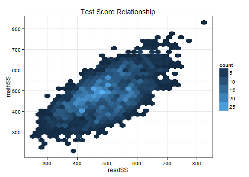

Student Test Scores

```r
library(ggplot2)  # Load graphics Package
qplot(readSS, mathSS, data = df, geom = "hex") + theme_bw() + opts(title = "Test Score Relationship")
```

# Handling Data in R

- R handles data differently than many other statistical packages
- In R, all elements are objects

```r
length(unique(df$school))
```

```
## [1] 173
```

```r
length(unique(df$stuid))
```

```
## [1] 1200
```

- Results of function calls can be stored

# How

- source editor: [RStudio](http://www.rstudio.org/) (perfect integration with [**knitr**](http://yihui.name/knitr/); one-click compilation); currently you have to use the [preview version](http://www.rstudio.org/download/preview) (>= 0.96.109)
- HTML5 slides converter: [pandoc](http://johnmacfarlane.net/pandoc/); this document was generated by: `pandoc -s -S -i -t dzslides --mathjax knitr-slides.md -o knitr-slides.html`
- the file [`knitr-slides.md`](https://github.com/yihui/knitr/blob/master/inst/examples/knitr-slides.md) is the markdown output from its [source](https://github.com/yihui/knitr/blob/master/inst/examples/knitr-slides.Rmd): `library(knitr); knitr('knitr-slides.Rmd')`
- or simple click the button `Knit HTML` in RStudio

# For ninjas

- you should tweak the default style; why not try some [Google web fonts](http://www.google.com/webfonts)? (think how painful it is to wrestle with fonts in LaTeX)
- pandoc provides 3 types of HTML5 slides (dzslides is one of them)
- you can tweak the default template to get better appearances
- if you have come up with a better dzslides template, please let me know or contribute to pandoc directly (e.g. `pre` blocks should have `max-width` and `max-height`)

# Reproducible research

It is good to include the session info, e.g. this document is produced with **knitr** version `0.5`. Here is my session info:

[session information not shown]